# Predição eleição deputados

Vinicius Brandão Araujo

25/11/2018

```r
train_data <- read.csv("data/train.csv")
test_data <- read.csv("data/test.csv")
```

# Descrição

Analise desenvolvido para a disciplina de Ciência de Dados Preditiva no período de 2018.2, o principal objetivo desta analise é prever quais candidatos à Câmara de Deputados serão eleitos nas eleições de 2014.

## Há desbalanceamento das classes (isto é, uma classe tem muito mais instâncias que outra)? Em que proporção? Quais efeitos colaterais o desbalanceamento de classes pode causar no classificador? Como você poderia tratar isso?

Como o principal intuito é a predição se um candidato foi eleito ou não, devemos considerar a classe situação e assim observar como está distribuida no conjunto de treinamento.

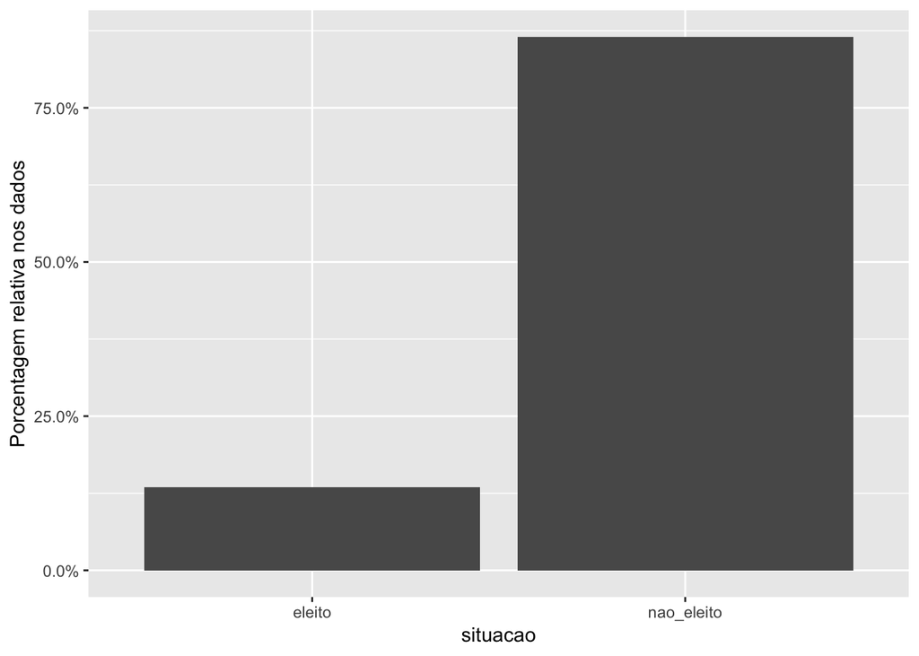

```r
train_data %>% ggplot(aes(situacao)) + geom_bar(aes(y = (..count..)/sum(..count..))) + scale_y_continuous(labels=scales::percent) + ylab("Porcentagem relativa nos dados")
```

Observamos que a situação não eleito está presente em mais de 80% dos dados de treinamento, nesse caso observamos uma desbalanceamento em uma grande proporção, considerando que eleito equivale a menos de 15% dos dados. Desse modo, pode ser criado um viés na qual o modelo aprenderá a ignorar as classes menos frequentes, levando a um impacto negativo na generalização do modelo e seu desempenho. O tratamento desses desbalanceamento pode ser dado de duas formas, são elas:

- Undersampling
- Oversampling

## Pre-processamento dos dados

Dividimos o conjunto de traino em traino e validação para poder validar o modelo.

```r
partition <- createDataPartition(y = train_data$situacao, p=0.75, list=FALSE)
set.seed(9560)
train <- train_data[partition, ]
validacao <- train_data[-partition, ]
```

Iremos “limpar os dados” desconsiderando algumas variaveis na qual não consideramos nescessaria para a geração dos modelos.

```r
set.seed(107)
train <- train %>%
          select(-partido,
                 -uf,-nome,
                 -estado_civil,
                 -ocupacao,-ano,
                 -cargo,-grau,-sexo,
                 -sequencial_candidato)

validacao <- validacao %>%
          select(-partido,
                 -uf,-nome,
                 -estado_civil,
                 -ocupacao,-ano,
                 -cargo,-grau,-sexo,
                 -sequencial_candidato)
test <- test_data %>%
          select(-partido,
                 -uf,-nome,
                 -estado_civil,
                 -ocupacao,-ano,
                 -cargo,-grau,-sexo)
```

Levando em consideração o desbalacemaneto existente, iremos utilizar a função SMOTE para o balancemaneto.

> A função SMOTE faz sobreamostragem de seu evento raro usando bootstrapping e k-neighbor mais próximo para criar sinteticamente observações adicionais daquele evento.

```r
set.seed(107)
train <- train %>% SMOTE(situacao ~ .,
                          data = .,
                          perc.over = 200,
                          perc.under=200)

train %>%
  group_by(situacao) %>%
  summarise(num = n()) %>%
  ungroup() %>%
  mutate(total = sum(num))
```

| situacao | num | total |
| --- | --- | --- |
| eleito | 2310 | 5390 |
| nao_eleito | 3080 | 5390 |

### Funções auxiliares

```r
F_Measure <- function(expected, predicted, ...) {
resultado<-  data.frame(expected=expected,
             prediction=predicted) %>%
      mutate(tp = ifelse(expected == "eleito" &
                         prediction == "eleito",1,0),
             fn = ifelse(expected == "eleito" &
                         prediction == "nao_eleito",1,0),
             fp = ifelse(expected == "nao_eleito" &
                         prediction == "eleito",1,0))
 resultado <-  resultado  %>%
    summarize(x = sum(tp),
              y = sum(fp),
              z = sum(fn)) %>%
    mutate(recall = x / (x + z),
           precision = x/ (x + y),
           f_measure = 2 * (precision * recall) / (precision + recall))
  resultado$x <- NULL
  resultado$y <- NULL
  resultado$z <- NULL
  return(resultado)
}
```

## Treine: um modelo de KNN, regressão logística, uma árvore de decisão e um modelo de adaboost. Tune esses modelos usando validação cruzada e controle overfitting se necessário, considerando as particularidades de cada modelo.

Para a geração dos modelos, iremos utilizar á biblioteca caret e assim trainar os modelos usando as funções trainControl e train.

### KNN

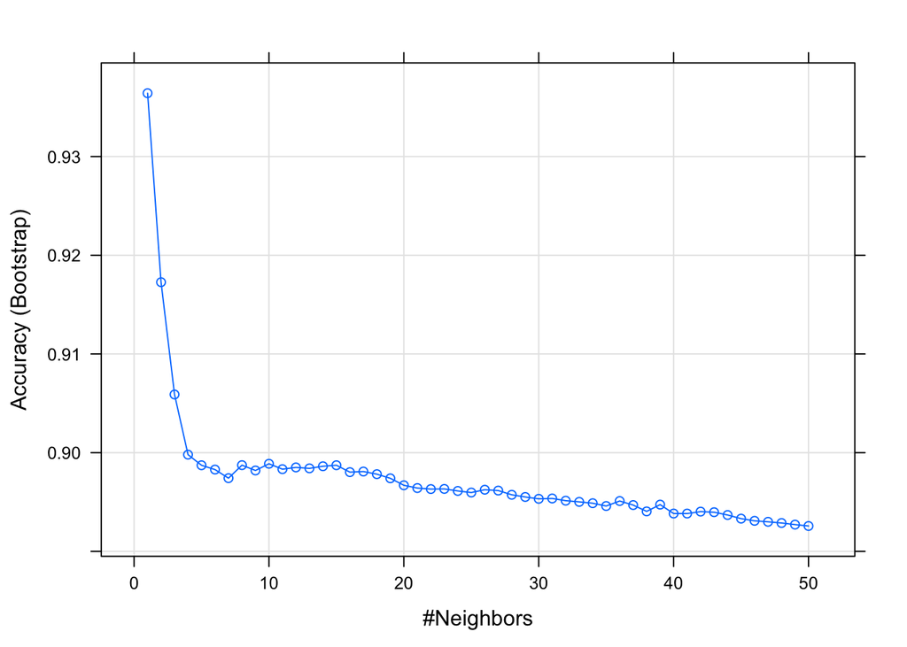

```r
cross_validation <- trainControl(method = "boot", classProbs = TRUE,savePredictions = "final")
k <- expand.grid(k = seq(from=1, to=50, by=1))
model_knn <- train(situacao ~ .,
                     data = train,
                     method = "knn",
                     tuneGrid = k,
                     preProc = c("center", "scale"),
                     trControl = cross_validation)
plot(model_knn)
```

```r
model_knn
```

```
## k-Nearest Neighbors
##
## 5390 samples
##   13 predictor
##    2 classes: 'eleito', 'nao_eleito'
##
## Pre-processing: centered (13), scaled (13)
## Resampling: Bootstrapped (25 reps)
## Summary of sample sizes: 5390, 5390, 5390, 5390, 5390, 5390, ...
## Resampling results across tuning parameters:
##
##   k   Accuracy   Kappa
##    1  0.9364174  0.8713464
##    2  0.9172715  0.8325078
##    3  0.9058946  0.8094180
```

[output cut: 50 more lines]

### Regressão Logística

```r
rlGrid <- expand.grid(cost = c(200,2,0.02),loss = c("L2","L2_dual","L2_primal"), epsilon = c(0.001,0.01))
cross_validation <- trainControl(method = "boot",classProbs = TRUE,savePredictions = "final")
model_logistic<- train(situacao ~ .,
                     data = train,
                     method = "regLogistic",
                     metric = "F1",
                     preProc = c("center", "scale"),
                     trControl = cross_validation)
```

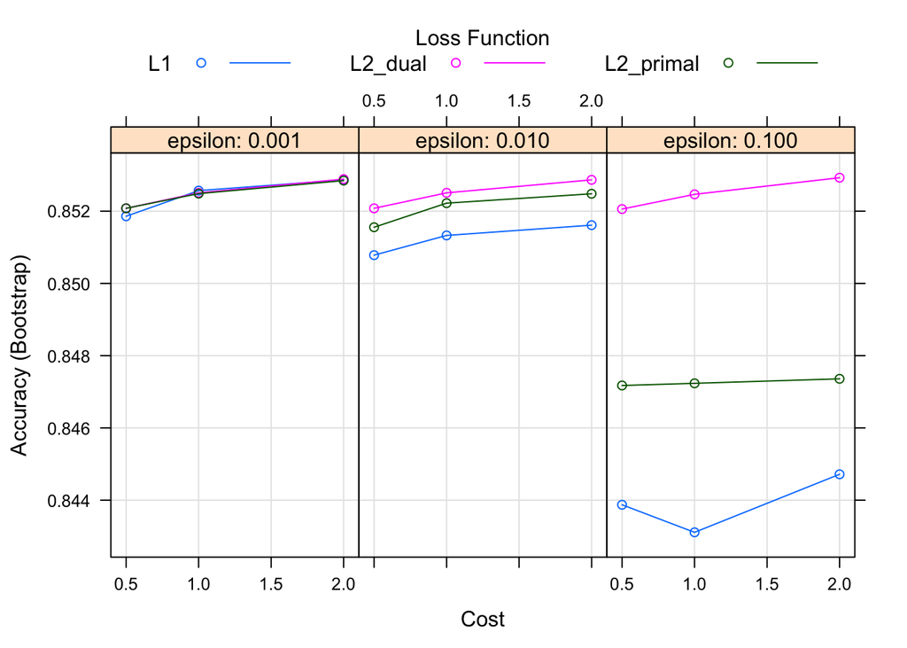

```r
plot(model_logistic)
```

```r
model_logistic
```

```
## Regularized Logistic Regression
##
## 5390 samples
##   13 predictor
##    2 classes: 'eleito', 'nao_eleito'
##
## Pre-processing: centered (13), scaled (13)
## Resampling: Bootstrapped (25 reps)
## Summary of sample sizes: 5390, 5390, 5390, 5390, 5390, 5390, ...
## Resampling results across tuning parameters:
##
##   cost  loss       epsilon  Accuracy   Kappa
##   0.5   L1         0.001    0.8518578  0.6933340
##   0.5   L1         0.010    0.8507820  0.6909459
##   0.5   L1         0.100    0.8438725  0.6754121
##   0.5   L2_dual    0.001    0.8520781  0.6938118
##   0.5   L2_dual    0.010    0.8520781  0.6938118
##   0.5   L2_dual    0.100    0.8520574  0.6937670
##   0.5   L2_primal  0.001    0.8520781  0.6938079
##   0.5   L2_primal  0.010    0.8515541  0.6927147
##   0.5   L2_primal  0.100    0.8471742  0.6826311
##   1.0   L1         0.001    0.8525684  0.6948993
##   1.0   L1         0.010    0.8513276  0.6922131
##   1.0   L1         0.100    0.8431100  0.6737518
##   1.0   L2_dual    0.001    0.8525064  0.6947654
##   1.0   L2_dual    0.010    0.8525064  0.6947654
##   1.0   L2_dual    0.100    0.8524651  0.6946808
##   1.0   L2_primal  0.001    0.8524852  0.6947203
##   1.0   L2_primal  0.010    0.8522213  0.6941986
##   1.0   L2_primal  0.100    0.8472342  0.6827527
##   2.0   L1         0.001    0.8528661  0.6955446
##   2.0   L1         0.010    0.8516122  0.6928377
##   2.0   L1         0.100    0.8447167  0.6772996
##   2.0   L2_dual    0.001    0.8528865  0.6955946
##   2.0   L2_dual    0.010    0.8528661  0.6955503
##   2.0   L2_dual    0.100    0.8529258  0.6956800
##   2.0   L2_primal  0.001    0.8528456  0.6955060
##   2.0   L2_primal  0.010    0.8524809  0.6947298
##   2.0   L2_primal  0.100    0.8473588  0.6830186
##
## Accuracy was used to select the optimal model using the largest value.
## The final values used for the model were cost = 2, loss = L2_dual
##  and epsilon = 0.1.
```

### Árvore de Decisão

```r
cross_validation <- trainControl(method = "boot",classProbs = TRUE,savePredictions = "final")

model_tree<- train(situacao ~ .,
                     metric = "F1",
                     data = train,
                     method = "rpart",
                     preProc = c("center", "scale"),
                     trControl = cross_validation)
```

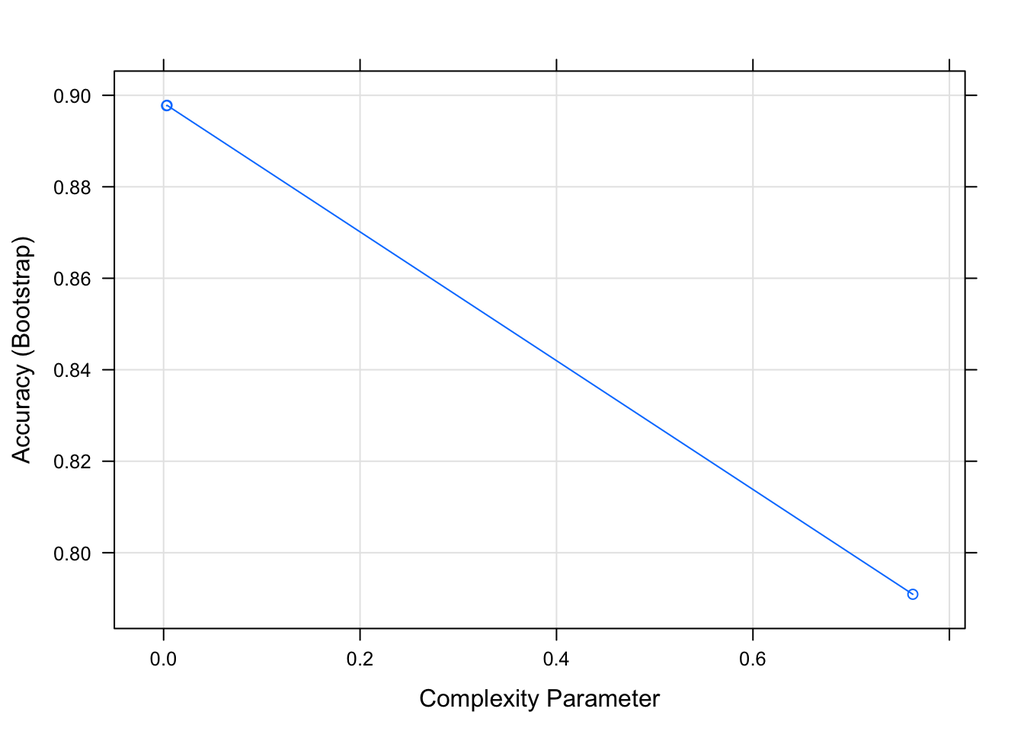

```r
plot(model_tree)
```

```r
model_tree
```

```
## CART
##
## 5390 samples
##   13 predictor
##    2 classes: 'eleito', 'nao_eleito'
##
## Pre-processing: centered (13), scaled (13)
## Resampling: Bootstrapped (25 reps)
## Summary of sample sizes: 5390, 5390, 5390, 5390, 5390, 5390, ...
## Resampling results across tuning parameters:
##
##   cp           Accuracy   Kappa
##   0.003030303  0.8977309  0.7934580
##   0.003463203  0.8978135  0.7937094
##   0.762770563  0.7909064  0.5350761
##
## Accuracy was used to select the optimal model using the largest value.
## The final value used for the model was cp = 0.003463203.
```

### Adaboost

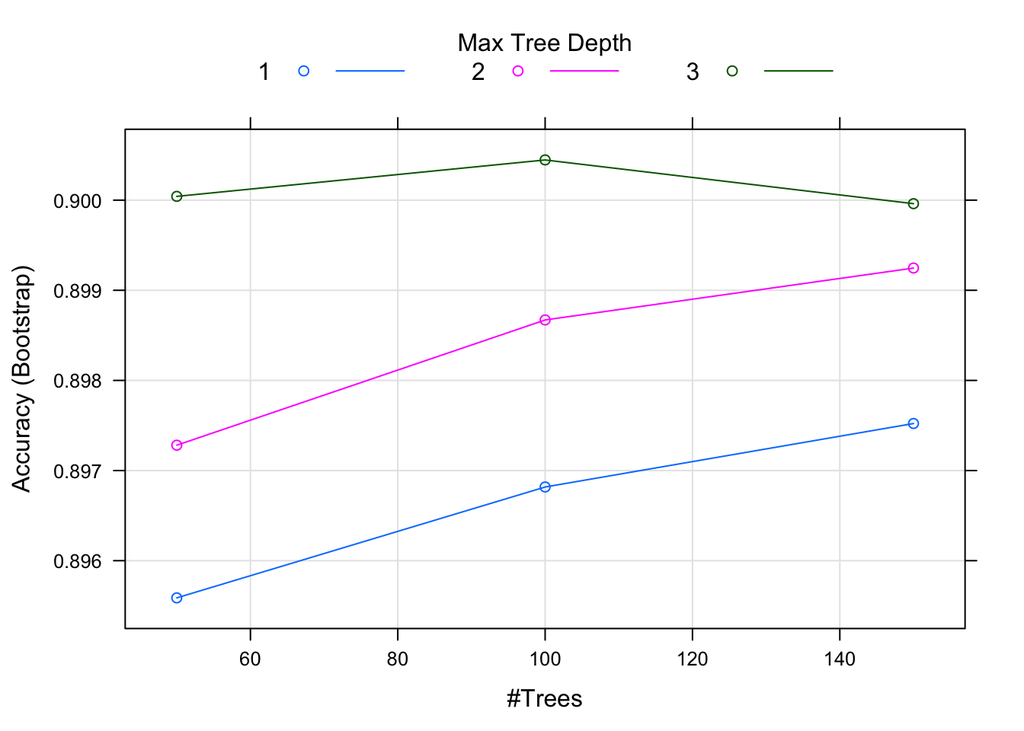

```r
cross_validation <- trainControl(method = "boot", verboseIter = FALSE,savePredictions = "final")

model_ada<- train(situacao ~ .,
                     data = train,
                     method = "ada",
                     preProc = c("center", "scale"),
                     trControl = cross_validation)
plot(model_ada)
```

```r
model_ada
```

```
## Boosted Classification Trees
##
## 5390 samples
##   13 predictor
##    2 classes: 'eleito', 'nao_eleito'
##
## Pre-processing: centered (13), scaled (13)
## Resampling: Bootstrapped (25 reps)
## Summary of sample sizes: 5390, 5390, 5390, 5390, 5390, 5390, ...
## Resampling results across tuning parameters:
##
##   maxdepth  iter  Accuracy   Kappa
##   1          50   0.8955875  0.7903926
##   1         100   0.8968176  0.7927371
##   1         150   0.8975222  0.7940847
##   2          50   0.8972812  0.7935771
##   2         100   0.8986709  0.7960540
##   2         150   0.8992470  0.7970305
##   3          50   0.9000419  0.7984702
##   3         100   0.9004463  0.7990530
##   3         150   0.8999611  0.7979590
##
## Tuning parameter 'nu' was held constant at a value of 0.1
## Accuracy was used to select the optimal model using the largest value.
## The final values used for the model were iter = 100, maxdepth = 3 and nu
##  = 0.1.
```

## Reporte precision, recall e f-measure no treino e validação. Há uma grande diferença de desempenho no treino/validação? Como você avalia os resultados?

### KNN

#### Treino

```r
model_knn %$%
  pred %>%
  F_Measure(expected = .$obs,
            predicted = .$pred)
```

| recall | precision | f_measure |
| --- | --- | --- |
| 0.9611252 | 0.8979529 | 0.9284658 |

#### Validação

```r
validacao %>%
  predict(object=model_knn,.) %>%
  F_Measure(validacao$situacao,.)
```

| recall | precision | f_measure |
| --- | --- | --- |
| 0.7539062 | 0.510582 | 0.6088328 |

Observamos que no conjunto de validação os valores de recall, precision e f_meansure baixo em relação ao conjunto de treino.

### Regressão Logística

#### Treino

```r
model_logistic %$%
  pred %>%
  F_Measure(expected = .$obs,
            predicted = .$pred)
```

| recall | precision | f_measure |
| --- | --- | --- |
| 0.7723432 | 0.8709968 | 0.8187088 |

#### Validação

```r
validacao %>%
  predict(object=model_logistic,.) %>%
  F_Measure(validacao$situacao,.)
```

| recall | precision | f_measure |
| --- | --- | --- |
| 0.7539062 | 0.6266234 | 0.6843972 |

Observamos que no conjunto de validação os valores de precision e f_meansure baixo em relação ao conjunto de treino.

### Árvore de Decisão

#### Treino

```r
model_tree %$%
  pred %>%
  F_Measure(expected = .$obs,
            predicted = .$pred)
```

| recall | precision | f_measure |
| --- | --- | --- |
| 0.931857 | 0.8437889 | 0.885639 |

#### Validação

```r
validacao %>%
  predict(object=model_tree,.) %>%
  F_Measure(validacao$situacao,.)
```

| recall | precision | f_measure |
| --- | --- | --- |
| 0.9570312 | 0.5010225 | 0.6577181 |

Observamos que no conjunto de validação os valores de precision e f_meansure baixo em relação ao conjunto de treino.

### Adaboost

#### Treino

```r
model_ada %$%
  pred %>%
  F_Measure(expected = .$obs,
            predicted = .$pred)
```

| recall | precision | f_measure |
| --- | --- | --- |
| 0.9334058 | 0.8484523 | 0.8889039 |

#### Validação

```r
validacao %>%
  predict(object=model_ada,.) %>%
  F_Measure(validacao$situacao,.)
```

| recall | precision | f_measure |
| --- | --- | --- |
| 0.921875 | 0.5279642 | 0.6714083 |

Observamos que no conjunto de validação os valores de precision e f_meansure baixo em relação ao conjunto de treino.

### Conclusão

Como observamos todos os modelos os valores de precision e f_mensure é baixo perante ao conjunto de treino.

## Interprete as saídas dos modelos. Quais atributos parecem ser mais importantes de acordo com cada modelo?

### KNN

```r
ggplot(varImp(model_knn))
```

[output not shown]

Observamos que para o knn os atributos mais importantes são:

- total_receita
- total_despesa
- recursos_de_pessoas_juridicas
- quantidade_fornecedores
- quantidade_despesas

### Regressão Logística

```r
ggplot(varImp(model_logistic))
```

[output not shown]

Observamos que para o regressão logística os atributos mais importantes são:

- total_receita
- total_despesa
- recursos_de_pessoas_juridicas
- quantidade_fornecedores
- quantidade_despesas

### Árvore de Decisão

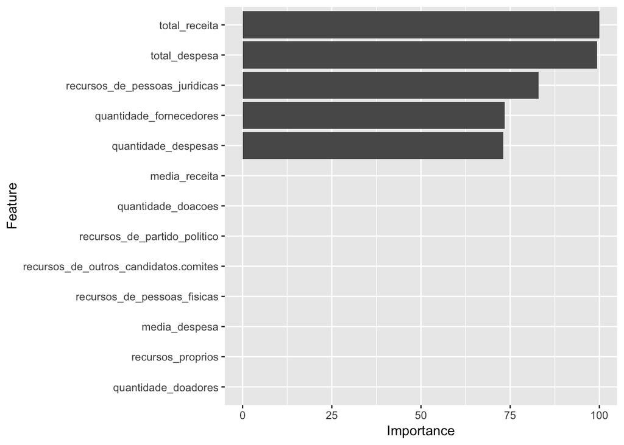

```r
ggplot(varImp(model_tree))
```

### Adaboost

```r
ggplot(varImp(model_ada))
```

[output not shown]

Observamos que para o adaboost os atributos mais importantes são:

- total_receita
- total_despesa
- recursos_de_pessoas_juridicas
- quantidade_fornecedores
- quantidade_despesas